# Next Word Prediction - Cousera Data Science Capstone Project - Week 2 Interim Report

Paul Jefferies

February 17, 2017

## Summary

Next word prediction is used in many forms today from web browser/search engine text entry to smart phone text entry to enable fast typing with. This project is an exercise in creating a ‘next word’ prediction algorithm and shiny app to demonstrate the algorithm working.

The development of this project has four main sections and status at the time of this interim report:

1. Exploratory Analysis of the supplied text files  
   - status: Complete but may be expanded in future
2. Development of databases to be used to predict ‘next words’  
   - status: Basic algorithm in-place. Some iterations evaluated. Much improvement needed to increase accuracy.
3. Evaluation of ‘next word’ prediction and optimization of many parameters including database size, prediction speed and othes  
   - status: Evaluation method in-place. Optimization in-process.
4. Implementing best prediction method in shiny web application for demonstration.  
   - status: Not started. Basic application outline planned.

## Exploratory Data Analysis

There are three text files supplied for word prediction learning and testing. Following is a summary of the contents of those files:

[output not shown]

Similarly, based on the large number of unique words, in order to limit the size of the database used to predict the ‘next word’, a subset the unique words will be used. The selection of the subset will be a topic in the algorithm development section.

To start that thought, we can look at a Pareto chart of the top 100 words and see that this covers 47.6% of the words.

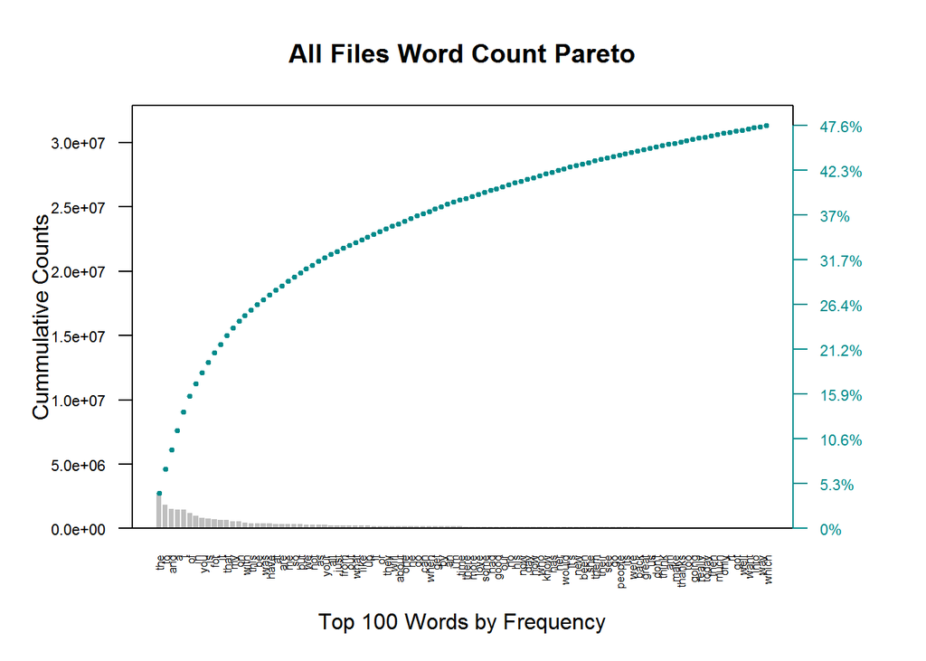

## Prediction Database Development

The prediction database development has proceeded in the following steps:

1. All prediction builds & tests are controlled with a center Queue text file that sets the folling parameters:  
   - Which text files to build from  
   - Number of lines from each text file  
   - Percent of lines from each text file to use for training (vs. test)  
   - Max. cumulative percent of unique words to save in training DB  
   - Penalties to apply in training to n-2, n-3, n-4 position words  
   - Penalties to apply in testing to n-2, n-3, n-4 position words
2. Using each file selected, a Markov Matrix is created storing a value relating each predictor word (in rows) and predicted word (in columns). The value is greater for predictor words closer to the predicted words (e.g. n-1 word has greater predictive value than n-2 word). The value is increase each time the predictor/predicted words are seen together.
3. Text lines of each file are filtered and split into words with the following: “aLine <- strsplit(tolower(gsub(”[^a-zA-Z ']“,”“, thisLine )),” “)[[1]]”. Thus, only letters and single-quotes are preserved as separate word characters.
4. The Markov Matrix is stored in a Sparse Matrix format allowing for very memory efficient storage compared to standare matrix data object.
5. Only words that in the top specified cumulative percentage are stored in the Markov Matrix.
6. A separate Word List is stored in highest to lowest frequency. With this same order, the Markov Matrix is stored using only the Word List index number for reference to save space.
7. The current database is very efficient in space (450 kb MAX) and prediction time (40 ms avgerage) although it is only based on 60% of the first 1000 lines of each of the three files. This small size is possibly causing the low accuracy rate. The main limiting factor in increasing the size is database creating time. For the best model, the database creating time is about 10 minutes.
8. Future database development is planned to evaluating the following:  
   - increasing number of words (with practicle training time) vs. DB size & prediction time  
   - Possible prediction using multi-word sequences  
   - Varying penalties for distance predictor word is from predicted word for both training and testing  
   - Predicting based on single file (i.e. using twitter only prediction model to predict twitter next words)  
   - Using varying percentages of most prevalent words to predict and be predicted

## Prediction Methodology Development and Evaluation

Prediction uses the sparse Markov Matrix developed as described above with the following method:

1. Lines from supplied text files that were not used for training are used for prediction testing.
2. A random point within the line is selected to choose a word to predict at position ‘n’.
3. Based on the previous (n-1) word, the highest likely hood next words are saved with their ‘power’ based on the number of times the two words were seen in sequence in training. No penalties are applied to the n-1 word powers.
4. Based on the previous (n-2, n-3, n-4) word, the highest likely hood next words are saved with their ‘power’ based on the number of times the two words were seen in sequence in training. Increasing penalties are applied to the powers from words farther away. If the same word is found from multiple reference words, the powers are added.
5. After finding the best words based the n-1 to n-4 words, the top number of words (based on highest power) desired are selected.
6. Current prediction accuracy results range from 21% to 32%.

## Prediction Implementation into Shiny Web Application

The Shiny Web application envisioned with have the following features

1. Inputs  
   - Text field for entering text  
   - Number selection for choosing number of predicted word to show  
   - ‘Predict’ button for starting prediction
2. Outputs  
   - List of predicted words as buttons to pick (when one is selected, the word is added to the text in the input field)